# Part II - (Loan Data from Prosper Analysis)

## by (Emmanuel Eshun)

## Investigation Overview

> The purpose of this project is to explore the variables that can affect the loan BorrowerAPR and to also get some knowledge about the relationships among some of the variables using summary statistics and data visualization.

## Dataset Overview

> This data set contains 113,937 loans with 81 variables on each loan, including loan amount, borrower rate (or interest rate), current loan status, borrower income, and many others.

## Distribution of Borrower APR

The distribution looks multimodal. A peak centered around 0.1 and around 0.2, with high counts around 0.35 about.

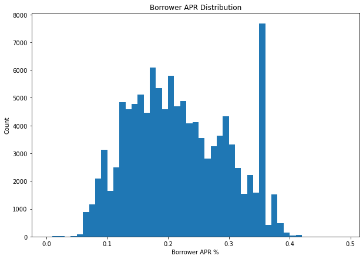

## Plot of Applicants States

Visually it can be estimated as the number of people in the scheme are still on going compared to cancelled which turned out to be the lowest.

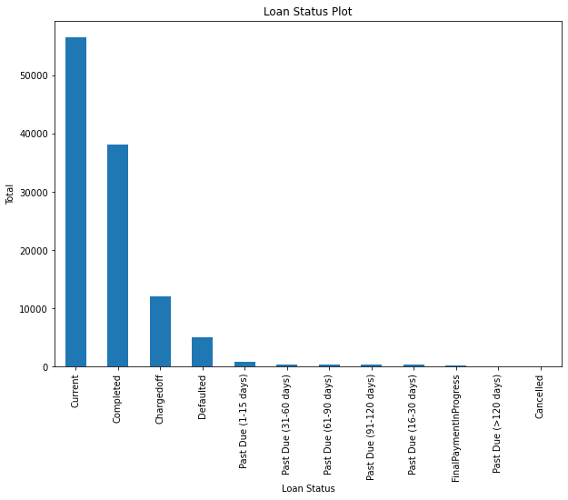

## Correlation between the attributes

There's a negative correlation between borrowerAPR and MonthlyLoanPayment, StatedMonthlyincome, whereas a positive one between the statedMonthlyincome and the monthly loan Payment

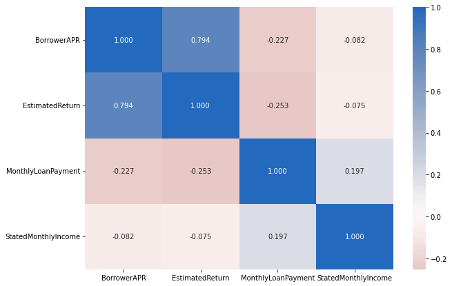

## Observed Relationships

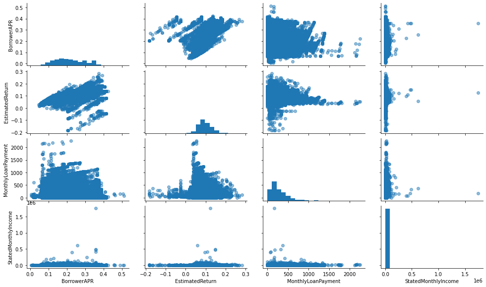

## Relationship between the BorrowerAPR, BorrowerRate and LenderYield

Interestingly We can see a strong positve relationship between these variables which conclude my findings that the BorrowerRate and the Lender Yield have some kind of effect on the BorrowerAPR.

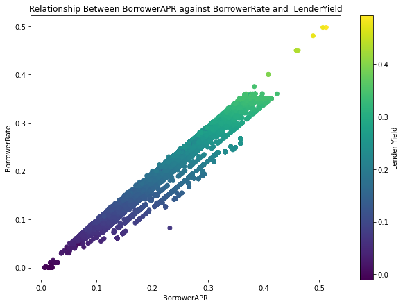